Statistički softver 4 - Seminarski rad Blagoje Ivanović

# Seminarski rad

U ovom dokumentu će biti predstavljena rešenja zadataka sa seminarskog i donekle detaljno objašnjene ideje kako je svaki zadatak uradjen. Za potrebe ovog seminarkog sam razvio R paket `ssotfveR` koji je dostupan na Github-u (https://github.com/blaza/ssoftver) i sadrži mnogo pomoćnih funkcija koje se ne tiču direktno zadataka na seminarskom ali se korišćenjem njih zadaci jako lako rešavaju.

Instalirajmo zato sad paket `ssoftver` (potreban je paket `devtools`):

```r
devtools::install_github("blaza/ssoftver")
```

Prvo ćemo rešiti zadatke vezane za `imager` paket.

# 1 Rad sa slikama

Pre negoli predjemo na sama rešenja zadataka, ukratko ćemo opisati nekoliko funkcija iz paketa `ssoftveR` koje se koriste.

## 1.1 Uvodna priča

Naime, u ovim zadacima uvek je potrebno uraditi neku manipulaciju sa oblikom na slici. U prvom zadatku je taj oblik kvadrat, u drugom može biti i krug, ali i neki nepoznati (treba da prepoznamo da li je krug/pravougaonik ili ne).

Stoga paket sadrži funkcije koje se bave pronalaženjem oblika na slici i njihovim klasifikovanjem. Te funkcije su `get_shapes` i `classify_shape`.

### 1.1.1 Pronalaženje i klasifikacija oblika

Prvo ćemo na primeru objasniti kako `get_shapes` pronalazi sve oblike na slici i vraća ih u listi. Princip je vrlo jednostavan. Pre svega:

> Oblik definišemo kao povezan skup piksela iste boje.

Učitajmo sliku koju koristimo za primer:

```r
library(imager)

im <- load.image("images/shapes_demo.png")
```

Ona ima dosta oblika na sebi koje ćemo detektovati i klasifikovati. Pogledajmo odmah krajnji rezultat, da znamo šta nas čeka, pa ćemo proći korak po korak šta se radi.

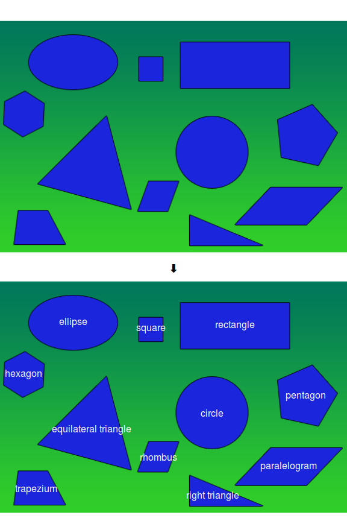

```r
library(ssoftveR)

# stavicemo dve slike jednu ispod druge i moramo da podesimo margine
layout(1:2)
par(mar = c(0.2,0,1.3,0))

# plotujemo pocetnu sliku
plot(im, axes = FALSE)

# nadjemo sve oblike na slici
shapes <- get_shapes(im)

# jos jednom plotujemo originalnu sliku pa cemo na nju dodati tekst
plot(im, axes = FALSE, main = "⬇")

# na svaki oblik dostampamo koji je oblik, tj. klasifikujemo ga
sapply(shapes, function(s) {
    cl <- classify_shape(s)
    text(s$centroid[1], s$centroid[2], cl[2], col = 'white', cex = 1)
})
```

Sve oblike smo tačno klasifikovali! Prodjimo sada osnovne korake.

#### Pronalaženje oblika

Prvo želimo da nadjemo povezane delove slike koji su identične boje. S tim ciljem, koristimo funkciju `solid_blobs` da pretvorimo sliku u tzv. pixset ( sliku čije je svaki piksel ili `TRUE` ili `FALSE`) koji nam za svaki piksel govori da li je ćlan homogene jednobojne sredine ili nije.

Pogledajmo rezultat koji dobijamo kad uradimo ovo za našu sliku:

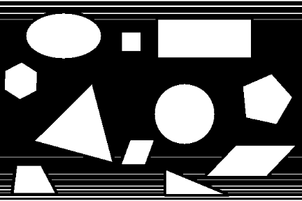

```r
plot(solid_blobs(im), axes = FALSE)
```

Svi oblici su postali beli (`= TRUE`), ali, nažalost, i za neke duge linije smo zaključili da su homogene. Postoji način da se to prevazidje, što radi `get_shapes` funkcija[^2] (videli smo da daje dobar rezultat), ali možemo i samo da povećamo veličinu okoline koju gledamo, npr. neka je sada dužina stranice krsta 9, a ne 5.

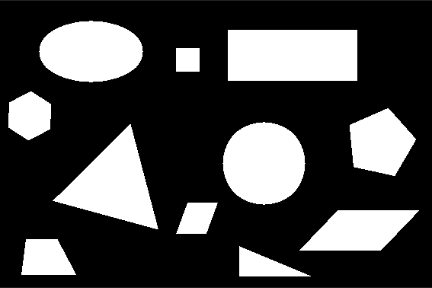

```r
blobs <- solid_blobs(im, cr_n = 9)
plot(blobs, axes = FALSE)
```

Sada iz ovakve slike vrlo jednostavno, uz pomoć paketa `imager`, da izvučemo sve povezane celine, koje ćemo pretvoriti u oblike. Za to nam služi funkcija `split_connected`. Dakle, jednostavno dobijamo:

```r
connected <- imager::split_connected(blobs)
print(connected)
```

```
## Image list of size 11
```

Dobili smo 11 slika, zapravo pixset-ova, gde svaki pixset predstavlja jedan oblik, tj jednu povezanu celinu u prethodnoj (crno-beloj) slici.

Na kraju, hoćemo da ove pixset-ove pretvorimo u nešto sa čim možemo lepo da radimo. To će biti objekti klase `shape`, koji su definisani u `ssoftveR` paketu.

```r
shapes <- lapply(connected, shape_from_pixset)
```

Vidimo da je funkcija `shape_from_pixset` glavna ovde. Demonstrirajmo šta ona radi i vidimo kako izgleda jedan objekat klase shape.

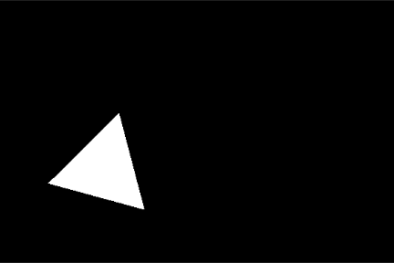

```r
# uzmimo jedan oblik
pixset <- connected[[7]]

# vidimo sta smo uzeli
plot(pixset, axes = FALSE)
```

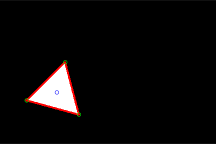

```r
# pretvorimo ga u objekat klase 'shape'
shape <- shape_from_pixset(pixset)

# prikazimo rezultat
plot(shape, axes = FALSE)
```

Vidimo da je slika za `shape` dosta drugačija od same slike za izvučeni pixset. Naime, vidimo da su sva temena obeležena, kao i sve stranice i centar oblika. To sve izvlači funkcija `shape_from_pixset`, uz korišćenje još nekih funkcija iz paketa, u koje nećemo sada zalaziti (naime, glavne od njih su [`get_sides`](https://github.com/Blaza/ssoftveR/blob/master/R/shape_geom.R#L1) i [`get_vertices`](https://github.com/Blaza/ssoftveR/blob/master/R/shape_geom.R#L103), ali su dosta komplikovane da bi se bavili njima ovde).

Pogledajmo strukturu objekta `shape` da steknemo sliku šta se tu sve nalazi.

```r
str(shape)
```

```
## List of 6
##  $ pixset  : 'pixset' logi [1:567, 1:378, 1, 1] FALSE FALSE FALSE FALSE FALSE FALSE ...
##  $ xy      :'data.frame':    8962 obs. of  2 variables:
##   ..$ x: num [1:8962] 171 172 170 171 172 169 170 171 172 168 ...
##   ..$ y: num [1:8962] 164 164 165 165 165 166 166 166 166 167 ...
##  $ contours:List of 1
##   ..$ :List of 3
##   .. ..$ level: num 1
##   .. ..$ x    : num [1:555] 70 70 70 71 72 ...
##   .. ..$ y    : num [1:555] 264 264 264 264 264 ...
##  $ centroid: Named num [1:2] 150 243
##   ..- attr(*, "names")= chr [1:2] "x" "y"
##  $ sides   :List of 3
##   ..$ :List of 4
##   .. ..$ x        : num [1:138] 71 72 73 74 75 76 77 78 79 80 ...
##   .. ..$ y        : num [1:138] 264 264 265 265 265 ...
##   .. ..$ direction: Named num [1:2] 0.965 0.264
##   .. .. ..- attr(*, "names")= chr [1:2] "x" "y"
##   .. ..$ slope    : Named num 15.3
##   .. .. ..- attr(*, "names")= chr "deg"
##   .. ..- attr(*, "class")= chr [1:2] "side" "list"
##   ..$ :List of 4
##   .. ..$ x        : num [1:138] 208 207 207 207 207 ...
##   .. ..$ y        : num [1:138] 301 300 299 298 297 ...
##   .. ..$ direction: Named num [1:2] -0.255 -0.967
##   .. .. ..- attr(*, "names")= chr [1:2] "x" "y"
##   .. ..$ slope    : Named num 75.2
##   .. .. ..- attr(*, "names")= chr "deg"
##   .. ..- attr(*, "class")= chr [1:2] "side" "list"
##   ..$ :List of 4
##   .. ..$ x        : num [1:103] 172 171 170 169 168 ...
##   .. ..$ y        : num [1:103] 164 164 165 166 167 ...
##   .. ..$ direction: Named num [1:2] -0.707 0.707
##   .. .. ..- attr(*, "names")= chr [1:2] "x" "y"
##   .. ..$ slope    : Named num -45
##   .. .. ..- attr(*, "names")= chr "deg"
##   .. ..- attr(*, "class")= chr [1:2] "side" "list"
##  $ vertices:List of 3
##   ..$ x    : num [1:3] 71 208 172
##   ..$ y    : num [1:3] 264 301 164
##   ..$ angle: num [1:3] 60.3 59.9 59.8
##  - attr(*, "class")= chr [1:2] "shape" "list"
```

Dakle, imamo originalni pixset, izvučene konture oblika, centar, sve stranice i sva temena. Stranice sadrže koordinate svih tačaka, (jedinični)vektor pravca i nagib. Temena sadrže koordinate, kao i ugao kod svakog temena.

#### Klasifikacija oblika

Do sada smo, dakle, izvukli sve oblike sa slike. Sada bi trebalo da ih klasifikujemo. U to nećemo toliko detaljno ulaziti, već ćemo samo navesti koje prediktore koristimo, pri čemu koristimo multinomni model (`multinom`) za klasifikaciju.

Dakle, prediktore koje koristimo za prepoznavanje oblika su:

1. **Disperzija udaljenosti od centra (`centroid_distance_variance`):**

   Kao što ime kaže, merimo disperziju udaljenosti tačaka sa konture oblika od centra. Ideja je da će to moći da razlikuje krug od elipse (kod kruga je disperzija bliska nuli), ali i mnoge druge oblike (kvadrat ima manju disperziju od pravougaonika i sl.).
2. **Broj temena (`vertex_count`):**

   Ovo je očigledno, krug i elipsa imaju 0, trouglovi 3, četvorouglovi 4 temena, itd. Ovaj prediktor čemo tretirati u modelu kao faktorsku promenljivu.
3. **Disperzija dužina stranica (`side_length_variance`):**

   Ovde je ideja slična kao u prvom prediktoru, ali je ovde poenta da će regularni poligoni imati disperziju približnu nuli (jednakostraničan trougao, kvadrat, romb, petougao, šestougao), a ostali oblici će imati neke veće vrednosti. Za krug i elipsu stavljamo da je ova disperzija nula.
4. **Disperzija uglova (`angle_variance`):**

   Merimo disperziju uglova na temenima. Ovo liči na prethodni prediktor, ali ovaj prediktor nam daje mogućnost da razlikujemo pravougaonike od paralelograma. Kvardat i romb imaju isti broj temena i disperziju dužina stranica (0), ali kod kvadrata je i disperzija uglova nula, dok kod romba nije.
5. **Disperzija zbirova susednih uglova (`adj_angle_sum_variance`):**

   Kod ovog prediktora inspiracija je bila to što znamo da je kod paralelograma zbir dva susedna ugla uvek 180°, pa je disperzija tad nula. Time dobijamo jedan način razlikovanja paralelograma i trapeza.

Kada smo to demistifikovali, prodjimo jedan primer klasifikacije, da vidimo šta radi i funkcja `classify_shape`. Klasifikovaćemo naš trougao od ranije.

```r
# uzmemo sve prediktore za nas shape. vracamo data.frame i ako negde imamo NA,
# pretvorimo ga u -1, da ne bismo imali problema sa modelom.
predictors <- get_shape_predictors(shape, df = TRUE, na_replacement = -1)
# stampamo rezultat
predictors
```

| centroid_distance_variance | vertex_count | side_length_variance | angle_variance | adj_angle_sum_variance |
| --- | --- | --- | --- | --- |
| 165.7733 | 3 | 0.0578475 | 0.0638487 | 0.2553947 |

Vidimo da imamo 3 temena, da su disperzije dužina stranica, uglova i zbirova susednih uglova bliske nuli, što je i očekivano jer je ovo jednakostraničan trougao. Da li će i naš model isto to reći? Pa hoće, videli smo već na početku.

```r
# klasifikujemo oblik koristeci multinom model "shapes_model"
shape_class <- as.character(predict(get_shapes_model(), predictors))

# da vidimo sta smo dobili
c(code = shape_class, long_name = shape_code_map[[shape_class]])
```

```
##                   code              long_name
##                   "et" "equilateral triangle"
```

Upravo smo ovaj rezultat i očekivali!

Dosta uvoda, predjimo sad na zadatke, ali to je sada trivijalno.

## 1.2 Zadaci

Ovde ćemo dati kodove koji rešavaju konkretne zadatke sa seminarskog.

### 1.2.1 Prvi zadatak

U prvom zadatku je trebalo da odredimo ugao rotacije pravougaonika, da rotiramo sliku tako da pravougaonik bude horizontalan i da je sačuvamo. To ćemo sve obuhvatiti funkcijom `first` (kod će biti na engleskom):

```r
first <- function(im, file_in = NULL, file_out = NULL) {
  if (!is.null(file_in)) im <- load.image(file_in)

  shape <- get_shapes(im)[[1]]
  side <- get_sides(shape)[[1]]
  center <- shape$centroid

  rot <- rotate_xy(im, -side$slope, center['x'], center['y'], boundary = 1)

  if (!is.null(file_out)) save.image(rot, file_out)

  # subtract slope from 90 because y axis is weird for images etc
  list(rotated = rot, angle = 90 - side$slope)
}
```

Dakle, primimo sliku `im` ili je učitamo iz fajla `file_in`, pronadjemo sve oblike na slici i uzmemo prvi, koji bi trebalo da je jedini, uzmemo jednu njegovu stranicu, rotiramo ga oko centra za (-)nagib stranice i sačuvamo sliku ako je dat fajl `file_out`. Na kraju vratimo rotiranu sliku i nagib pravougaonika u listi.

Pogledajmo kod u akciji:

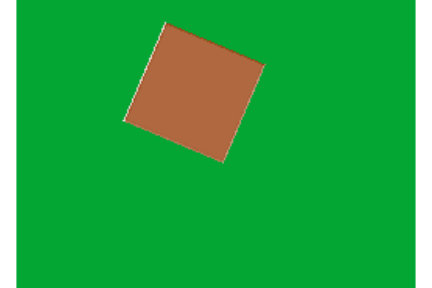

```r
im <- load.image("images/first_test.png")
plot(im, axes = FALSE)
```

```r
res <- first(im)
print(res$angle)
```

```
##      deg
## 66.96448
```

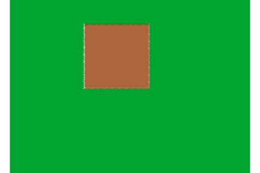

```r
plot(res$rotated, axes = FALSE)
```

```r
print(first(res$rotated)$angle)
```

```
##      deg
## 179.7518
```

Vidimo da je greška u rotaciji manja od 1°.

### 1.2.2 Drugi zadatak

Ovaj zadatak je malo teži. Trebalo je da se proveri da li je na slici tačno jedan crni ili beli pravougaonik (krug) i, ako jeste, da se vrate koordinate njegovih temena (njegovog centra).

Prvo ćemo definisati funkciju koja klasifikuje sve oblike na slici i vrati i njihove boje. Ovde koristimo jako pametnu funkciju `rgb2col` iz paketa `ssoftveR`, koja odredjuje tačno ime boje (iz palete dostupne R-u) na osnovu njenih RGB vrednosti. Ona u suštini bira onu boju koja je najbliža datoj RGB vrednosti, ali koristeći naprednu metriku datu u `colorscience` paketu. Ta metrika je [deltaE2000](https://en.wikipedia.org/wiki/Color_difference#CIEDE2000).

```r
shape_names_and_colors <- function(im, shapes = NULL) {
  im <- flatten.alpha(im)

  if (is.null(shapes)) shapes <- get_shapes(im)

  # we transpose to get code and long_name columns
  shape_classes <- t(sapply(shapes, classify_shape))
  shape_colors <- sapply(shapes, function(s) {
                           cxy <- round(s$centroid)
                           # rescale rgb to 0-255
                           rgb <- im[cxy[1], cxy[2], 1, ] * 255
                           # get color name
                           rgb2col(rgb)
                  })
  cbind(shape_classes, color = shape_colors)
}
```

Proverimo je na našoj slici

```r
print(shape_names_and_colors(im))
```

```
##      code long_name color
## [1,] "sq" "square"  "salmon3"
```

Dakle ovo je neka boja lososa, recimo…

Sada jednostavno rešavamo drugi zadatak u funkciji `second`.

```r
second <- function(im, file_in = NULL, circle = FALSE) {
  if (!is.null(file_in)) im <- load.image(file_in)

  shapes <- get_shapes(im)
  snc <- shape_names_and_colors(im, shapes)

  if (!circle) {
    if (length(snc[ ,1]) != 1)
      stop("The image doesn't contain exactly one shape!")

    if (!(snc[1, 'code'] %in% c('sq', 're')))
      stop("The shape in the image isn't a rectangle or a square!")

    if(!(snc[1, 'color'] %in% c("white", "black")))
      stop("The shape in the image isn't white or black!")

    # plot shape
    plot(shapes[[1]], axes = FALSE)

    # return shape vertices (and their coordinates)
    shapes[[1]]$vertices

  } else {
    if (length(snc[ ,1]) != 1)
      stop("The image doesn't contain exactly one shape!")

    if (!(snc[1, 'code'] == "ci"))
      stop("The shape in the image isn't a circle!")

    if(!(snc[1, 'color'] %in% c("white", "black")))
      stop("The shape in the image isn't white or black!")

    shape <- shapes[[1]]

    plot(shape, axes = FALSE)

    contour <- shape$contours[[1]]

    # Calculating distances from the centroid of all points on the contour
    distances <- sqrt((contour$x - shape$centroid['x'])^2 +

                      (contour$y - shape$centroid['y'])^2)

    # return circle center and radius
    cbind(t(shape$centroid), radius = mean(distances))
  }
}
```

Ako stavimo `circle = TRUE`, rešavamo zadatak 2.v, inače rešavamo 2.b.

Probajmo našu sliku

```r
second(im, circle = FALSE)
```

```
## Error in second(im, circle = FALSE): The shape in the image isn't white or black!
```

```r
second(im, circle = TRUE)
```

```
## Error in second(im, circle = TRUE): The shape in the image isn't a circle!
```

Radi lepo, hajde sada par slika za koje će da prodje.

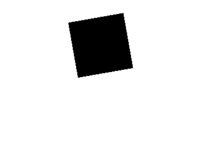

```r
im1 <- load.image('images/second_test_square.bmp')
plot(im1, axes = FALSE)
```

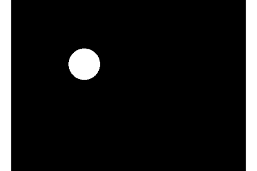

```r
im2 <- load.image('images/second_test_circle.png')
plot(im2, axes = FALSE)
```

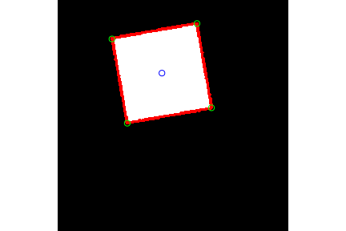

```
## $x
## [1]  61.000  78.000 171.001 155.000
##
## $y
## [1]  44.001 137.001 120.000  26.999
##
## $angle
## [1] 90.04117 90.01907 89.86820 90.07157
```

```r
second(im1)
```

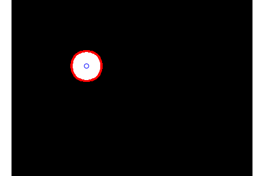

```
##             x        y   radius
## [1,] 151.0373 133.0373 30.25643
```

```r
second(im2, circle = TRUE)
```

I to bi bilo sve što se tiče rada sa slikama.

# 2 Minolovac

Sav kod potreban za rešavanje dela seminarskog koji se tiče Minolovca se nalazi na Github-u, na repozitorijumu [`blaza/minesolver`](https://github.com/blaza/minesolver). Funkcije iz ovog projekta nisam stavio u paket `ssoftveR` jer mislim da im tu nije mesto, budući da direktno rešavaju veliki deo zadataka, pa nisu za širu upotrebu.

Pored toga, u `minesolver` projektu se nalazi i kod za automatsko igranje Minesweeper igre (Windows 7 verzija igre). Fajlovi koji to regulišu su [`player.R`](https://github.com/Blaza/minesolveR/blob/master/player.R) koji na osnovu slike table daje sledeći potez, `automine.exe` koji predstavlja program koji zapravo klikće po ekranu i [`play.R`](https://github.com/Blaza/minesolveR/blob/master/play.R) koji ostvaruje komunikaciju izmedju prethodna dva programa. Kako to sve radi može se videti na [ovom video klipu](https://www.youtube.com/watch?v=8VdXCg1oemQ).

Zato ćemo prvo, koristeći paket `git2r`, preuzeti sve skripte iz projekta `minesolver`, pa preći na rešenja zadataka, koja su velikim delom sadržana u projektu. Funkcije koje se koriste su dokumentovane u kodu, pa se nećemo previše baviti time, već ćemo po potrebi predstaviti neke ideje koje su bitnije.

Dakle, da preuzmemo projekat…

```r
# kloniramo u folder minesolver
git2r::clone("https://github.com/blaza/minesolver", "./minesolver")
```

```
## cloning into './minesolver'...
## Receiving objects:   1% (2/129),    9 kb
## Receiving objects:  11% (15/129),    9 kb
## Receiving objects:  21% (28/129),  595 kb
## Receiving objects:  31% (40/129),  643 kb
## Receiving objects:  41% (53/129),  643 kb
## Receiving objects:  51% (66/129),  723 kb
## Receiving objects:  61% (79/129),  819 kb
## Receiving objects:  71% (92/129),  819 kb
## Receiving objects:  81% (105/129), 4780 kb
## Receiving objects:  91% (118/129), 10513 kb
## Receiving objects: 100% (129/129), 10513 kb, done.
```

```
## Local:    master /home/blaza/projects/stats/ss4/seminarski/minesolver/
## Remote:   master @ origin (https://github.com/blaza/minesolver)
## Head:     [bd5ff76] 2017-08-10: Update model
```

Ovime smo “klonirali” repozitorijum sa Github-a koristeći u pozadini komandu [`git clone`](https://www.atlassian.com/git/tutorials/setting-up-a-repository/git-clone). Za svakog ko želi da mu prosečna udaljenost od računara tokom dana bude manja od 2m, od ogromnog je značaja da nauči da koristi [`git`](https://git-scm.com/). Neki izvori za učenje koje sam našao su:

- [Happy Git with R](http://happygitwithr.com/) - namenjen konkretno R korisnicima
- Git and Github - R packages by Hadley Wickham - takodje namenjen R korisnicima, kraći od Happy Git with R, ali može da sadrži neko zrno znanja koje nema tamo.
- [Try Git](https://try.github.io/) - 15-minutni uvod u Git

Dobro, da se vratimo na temu… Prelazimo na zadatke.

## 2.1 Zadaci

### 2.1.1 Treći zadatak

U ovom zadatku nam je posao da odredimo dobar model za odredjivanje koji broj se nalazi na polju sa table Minolovca. Slike koje koristimo za obučavanje se nalaze u folderu `minesolver/mines_img/`, a slike koje ćemo koristiti za testiranje modela su u `minesolver/mines_img/control`.

#### Skup za obučavanje

Da ne bismo ručno klasifikovali polja za skupove za obučavanje i kontrolu, iskoristićemo fajlove `minesolver/tr_cls.RDS` i `minesolver/ct_cls.RDS` koje smo pripremili ranije. Oni sadrže klase polja (brojeve koji se nalaze na poljima), a polja ćemo izvući sa slika i kombinovati klase i prediktore da dobijemo skup za obučavanje i kotrolni skup. Počećemo od skupa za obučavanje. Ovo je blago modifikovano parče koda iz fajla `minesolver/mines_training.R` koji je izvorno korišćen za model.

```r
library(imager)
library(ssoftveR)
source("minesolver/mines_predictors.R")

# load all images for training
files <- Sys.glob(paste("minesolver", "mines_img/*.png", sep = '/'))
images <- lapply(files, load.image)


# set predictors we want to use
predictors <- c("x_arc_length", "y_arc_length")

# extract fields from images
ext_fields <- lapply(images, function(im) {
                   im <- im %>% resize(780, 780)
                   extract_fields(process_img(im),
                                  get_boundaries(decolor(im), prob = 0.95))
              })

# combine the fields into one list
fields <- do.call(c, ext_fields)

# calculate predictors for the fields
tr_preds <- get_field_predictors(predictors, fields, FALSE)

# load saved training classes
tr_cls <- readRDS("minesolver/tr_cls.RDS")

# combine predictors and classes into one training set data.frame
tr_set <- cbind(tr_preds, class = tr_cls)
```

Ovime smo generisali skup za obučavanje. Pogledajmo kako izgleda pa ćemo objasniti prediktore koje koristimo.

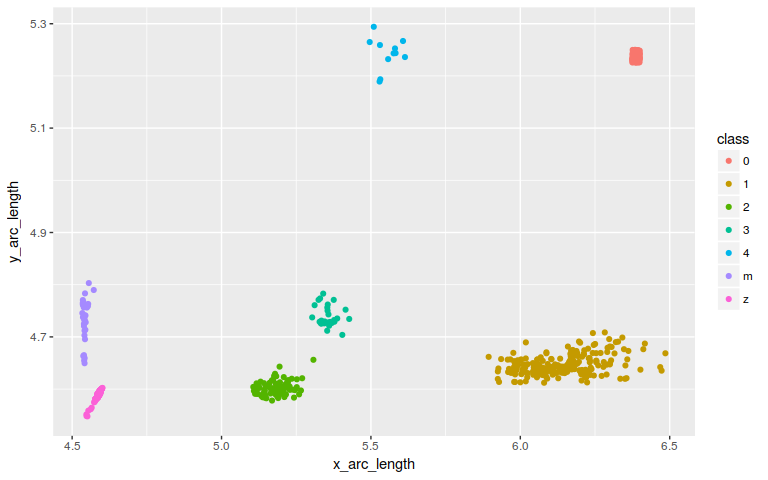

```r
library(ggplot2)
ggplot(tr_set, aes(x = x_arc_length, y = y_arc_length, color = class)) +
    geom_point()
```

Vidimo da su klase lepo razdvojene, možemo očekivati da ćemo imati dobar model.

#### Prediktori

Vizuelizujmo sada prediktore koje koristimo, jer slika govori hiljadu reči. Kod koji ovo radi se nalazi u fajlu `minesolver/pred_visual.R`.

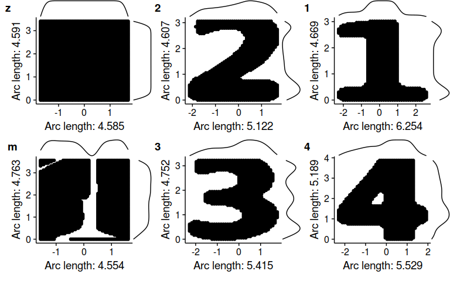

```r
source("minesolver/pred_visual.R")
visualise_predictors(fields, tr_cls)
```

Vidi se da svaki broj ima različit oblik krive koja predstavlja gustinu piksela po x i y koordinatama. Kao prediktore `x_arc_length` i `y_arc_length` mi jednostavno koristimo odgovarajuće dužine tih krivih.

#### Kontrolni skup

Hajde sad da formiramo i kontrolni skup. Na skoro isti način to radimo kao i što smo skup za obučavanje.

```r
library(imager)
library(ssoftveR)
source("minesolver/mines_predictors.R")

# load all images for training
files <- Sys.glob(paste("minesolver", "mines_img/control/*.png", sep = '/'))
images <- lapply(files, load.image)


# set predictors we want to use
predictors <- c("x_arc_length", "y_arc_length")

# extract fields from images
ext_fields <- lapply(images, function(im) {
                   im <- im %>% resize(780, 780)
                   extract_fields(process_img(im),
                                  get_boundaries(decolor(im), prob = 0.95))
              })

# combine the fields into one list
fields <- do.call(c, ext_fields)

# calculate predictors for the fields
ct_preds <- get_field_predictors(predictors, fields, FALSE)

# load saved test classes
ct_cls <- readRDS("minesolver/ct_cls.RDS")

# combine predictors and test into one control set data.frame
ct_set <- cbind(ct_preds, class = ct_cls)
```

Sada možemo da predjemo na pravljenje modela.

#### Modeli

Napravićemo 3 modela (LDA, QDA i multinomni) i testirati njihovu preciznost da ustanovimo koji je najbolji.

##### - LDA

Prvi na listi modela koje ćemo da probamo je LDA model. Jednostavno se kreira koristeći funkciju `lda` iz `MASS` paketa i generisani skup za obučavanje.

```r
library(MASS)

lda_model <- lda(class ~ . , data = tr_set)
```

Koristeći paket `klaR` možemo videti podelu koju napravi LDA model u prostoru.

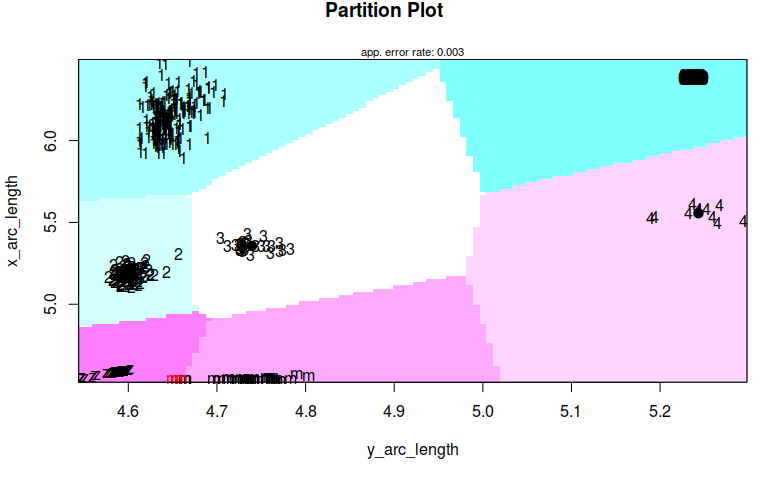

```r
library(klaR)

partimat(class ~ . , data = tr_set, method = "lda")
```

Pogledajmo kako se pokazao ovaj model, prvo na skupu za obučavanje

```r
# get predicted classes
predictions <- predict(lda_model, tr_set[ , -3])$class

# compare real values and predicted
print(table(tr_set[ , 3], predictions))
```

```
##    predictions
##       0   1   2   3   4   m   z
##   0 196   0   0   0   0   0   0
##   1   0 231   0   0   0   0   0
##   2   0   0  86   0   0   0   0
##   3   0   0   0  28   0   0   0
##   4   0   0   0   0  11   0   0
##   m   0   0   0   0   0  31   3
##   z   0   0   0   0   0   0 386
```

```r
# see the accuracy
mean(tr_set[ , 3] == predictions)
```

```
## [1] 0.9969136
```

Dakle imamo tačnost 99.69% na skupu za obučavanje, iz tabele vidimo da je pomešao zatvoreno polje i minu 3 puta.

Predjimo na kontrolni skup:

```r
# get predicted classes
predictions <- predict(lda_model, ct_set[ , -3])$class

# compare real values and predicted
print(table(ct_set[ , 3], predictions))
```

```
##    predictions
##      0  1  2  3  4  m  z
##   0 63  0  0  0  0  0  0
##   1  0 46  0  0  0  0  0
##   2  0  0 18  0  0  0  0
##   3  0  0  0  3  0  0  0
##   4  0  0  0  0  3  0  0
##   m  0  0  0  0  0 13  0
##   z  0  0  0  0  0  0 16
```

```r
# see the accuracy
mean(ct_set[ , 3] == predictions)
```

```
## [1] 1
```

Na kontrolnom skupu smo sve pogodili! Preciznost je 100%.

Ovo će biti teško pobediti. Idemo na QDA model.

##### - QDA

Ponovićemo isti postupak kao i za LDA model

```r
library(MASS)

qda_model <- qda(class ~ . , data = tr_set)
```

Koristeći paket `klaR` možemo videti i podelu koju napravi QDA model u prostoru.

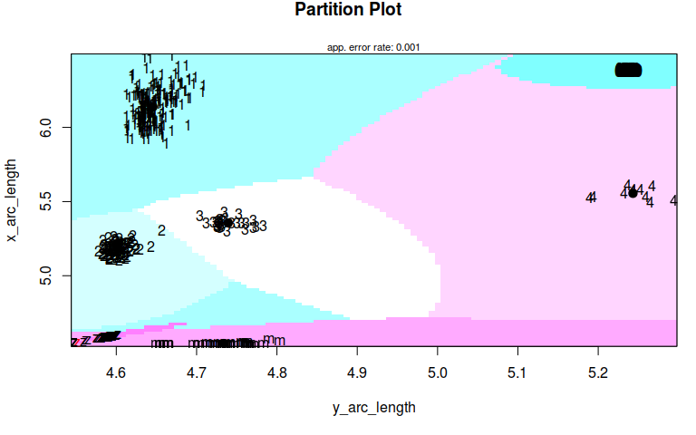

```r
library(klaR)

partimat(class ~ . , data = tr_set, method = "qda")
```

Proverimo model na skupu za obučavanje…

```r
# get predicted classes
predictions <- predict(qda_model, tr_set[ , -3])$class

# compare real values and predicted
print(table(tr_set[ , 3], predictions))
```

```
##    predictions
##       0   1   2   3   4   m   z
##   0 196   0   0   0   0   0   0
##   1   0 231   0   0   0   0   0
##   2   0   0  86   0   0   0   0
##   3   0   0   0  28   0   0   0
##   4   0   0   0   0  11   0   0
##   m   0   0   0   0   0  34   0
##   z   0   0   0   0   0   1 385
```

```r
# see the accuracy
mean(tr_set[ , 3] == predictions)
```

```
## [1] 0.9989712
```

Dakle imamo tačnost 99.89% na skupu za obučavanje, iz tabele vidimo da je pomešao zatvoreno polje i minu jedanput. I LDA i QDA imaju blagi problem sa minama i zatvorenim poljima iz nekog razloga, ali QDA je ipak tačniji.

Predjimo na kontrolni skup:

```r
# get predicted classes
predictions <- predict(qda_model, ct_set[ , -3])$class

# compare real values and predicted
print(table(ct_set[ , 3], predictions))
```

```
##    predictions
##      0  1  2  3  4  m  z
##   0 63  0  0  0  0  0  0
##   1  0 46  0  0  0  0  0
##   2  0  0 18  0  0  0  0
##   3  0  0  0  3  0  0  0
##   4  0  0  0  0  3  0  0
##   m  0  0  0  0  0 13  0
##   z  0  0  0  0  0  0 16
```

```r
# see the accuracy
mean(ct_set[ , 3] == predictions)
```

```
## [1] 1
```

Na kontrolnom skupu smo opet sve pogodili! Preciznost je 100%, kao i za LDA, premda smo ovaj put bolje prošli na skupu za obučavanje, pa je QDA za nijansu bolji model.

Da li će multinomni model biti bolji čak i od QDA? Saznaćemo u sledećem odeljku.

##### - Multinomni

Za kraj ostaje da proverimo i multinomni model. Njega pravimo koristeći se paketom `nnet` na sledeći način:

```r
library(nnet)

mnm_model <- multinom(class ~ . , data = tr_set, maxit = 1e3)
```

Nažalost nemamo način da vizuelizujemo podelu koji napravi multinom, pa ćemo odmah preći na testiranje.

Prvo skup za obučavanje

```r
# get predicted classes
predictions <- predict(mnm_model, tr_set[ , -3])

# compare real values and predicted
print(table(tr_set[ , 3], predictions))
```

```
##    predictions
##       0   1   2   3   4   m   z
##   0 196   0   0   0   0   0   0
##   1   0 231   0   0   0   0   0
##   2   0   0  86   0   0   0   0
##   3   0   0   0  28   0   0   0
##   4   0   0   0   0  11   0   0
##   m   0   0   0   0   0  34   0
##   z   0   0   0   0   0   0 386
```

```r
# see the accuracy
mean(tr_set[ , 3] == predictions)
```

```
## [1] 1
```

Na skupu za obučavanje sve pogadjamo! Da vidimo i kontrolni skup…

```r
# get predicted classes
predictions <- predict(mnm_model, ct_set[ , -3])

# compare real values and predicted
print(table(ct_set[ , 3], predictions))
```

```
##    predictions
##      0  1  2  3  4  m  z
##   0 63  0  0  0  0  0  0
##   1  0 46  0  0  0  0  0
##   2  0  0 18  0  0  0  0
##   3  0  0  0  3  0  0  0
##   4  0  0  0  0  3  0  0
##   m  0  0  0  0  0 13  0
##   z  0  0  0  0  0  0 16
```

```r
# see the accuracy
mean(ct_set[ , 3] == predictions)
```

```
## [1] 1
```

Ne iznenadjuje da nam je i ovde preciznost 100%. Dakle multinomni model nam je najbolji, budući da smo sve slike tačno klasifikovali. Njega naravno i koristimo pri igranju Minesweeper igre na Windows-u.

### 2.1.2 Četvrti zadatak

Ovaj zadatak se značajno lakše radi jer je praktično već rešen u `minesolver`, ali ćemo opisati ukratko principe na kojim funkcionišu rešenja.

Prve svega, opisaćemo jedan objekat koji se prožima kroz sve zadatke i čini osnovu svih zadataka koji imaju veze sa logikom i pravilima minolovca. To je “matrica okolina”. Ona nam omogućava da na jako brz i lak način implementiramo logiku minolovca.

Matricu okolina pravimo tako što za svako polje uzmemo sva polja koja ga okružuju i stavimo ih u jedan red matrice. Da vidimo kako to izgleda (koristimo tablu 3x3 sa 3 mine koju smo u tajnosti napravili, a videćemo i kako kasnije):

```r
# fajl u kom je kod za matrice okolina
source("minesolver/neighbours.R")

# stampamo tablu
print(board)
```

```
##      [,1] [,2] [,3]
## [1,] "1"  "2"  "m"
## [2,] "m"  "3"  "1"
## [3,] "m"  "2"  "0"
```

```r
# pravimo matricu okolina
print(get_neighbour_matrix(board))
```

```
##       (1,1) (0,1) (-1,1) (1,0) (0,0) (-1,0) (1,-1) (0,-1) (-1,-1)
##  [1,] "3"   "2"   NA     "m"   "1"   NA     NA     NA     NA
##  [2,] "2"   "3"   "2"    "m"   "m"   "1"    NA     NA     NA
##  [3,] NA    "2"   "3"    NA    "m"   "m"    NA     NA     NA
##  [4,] "1"   "m"   NA     "3"   "2"   NA     "m"    "1"    NA
##  [5,] "0"   "1"   "m"    "2"   "3"   "2"    "m"    "m"    "1"
##  [6,] NA    "0"   "1"    NA    "2"   "3"    NA     "m"    "m"
##  [7,] NA    NA    NA     "1"   "m"   NA     "3"    "2"    NA
##  [8,] NA    NA    NA     "0"   "1"   "m"    "2"    "3"    "2"
##  [9,] NA    NA    NA     NA    "0"   "1"    NA     "2"    "3"
## attr(,"board_dim")
## [1] 3 3
```

U srednjoj koloni je (odmotana u vektor) matrica koja predstavlja tablu, a nazivi kolona pokazuju u kom pravcu je odredjeno polje od srednjeg. Tako u svakom redu imamo okolinu srednjeg polja, s tim da za polja na ivici table stoji NA u pravcima na kojima ne postoji ništa.

U principu jedino pravilo minolovca je da oko svakog polja ima tačno onoliko mina koliko piše na polju. Ova matrica okolina nam omogućava da jednostavno radimo sa tom logikom budući da se sve svodi na brojanje mina u svakom redu i poredjenjem sa srednjim brojem.

Predjimo na konkretna rešenja zadataka.

#### (a) *resi_tablu(matrica, …)*

Treba da definišemo funkciju `resi_tablu(matrica, ...)` koja rešava datu tablu Minolovca.

```r
source("minesolver/solver.R")
resi_tablu <- function(matrica, broj_mina) solve_board(matrica, broj_mina)
```

Funkcija `solve_board` rešava tablu primenjujući uzastopno dve tehnike. Prva tehnika je direktna upotreba pravila Minolovca da se odrede mesta koja su sigurno mine ili sigurno nisu mine. To je najosnovnija logika.

Druga tehnika je “metod kontradikcije”. On funkcioniše tako što nadjemo sva neotvorena polja koja se nalaze uz otvorena (za ona polja koja su okružena samo zatvorenim nemamo nikakvu informaciju za rešavanje), pa krenemo redom i ponavaljamo sledeći postupak za svako od tih polja:

1. Stavimo minu na polje
2. Rešimo tablu koristeći osnovnu logiku
3. Ako smo dobili kontradiktornu (nevalidnu) tablu, označimo da na tom polju ne sme biti mina.

Analogan postupak ponovimo i stavljajući na početku da na polju nije mina i vidimo da li dolazi do kontradikcije, pa da mora da bude mina na tom polju.

#### (b) *MK_simulacija(matrica, …)*

Zadatak je da od preostalih neotvorenih polja odredimo ono koje ima najveću i ono koje ima najmanju verovatnoću da ima minu na sebi. Ovo radimo u funkciji `get_mine_probs` iz `minesolver/solver.R` tako što preostali broj mina mnogo puta razbacamo po zatvorenim poljima i vidimo da li je tabla validna, pa na kraju vidimo koliko puta je procentualno svako polje bilo prisutno u validnoj tabli.

```r
source("minesolver/solver.R")

MK_simulacija <- function(matrica, broj_mina) {
    # odredimo verovatnoce pojave matrica za svako polje
    prob_mat <- get_mine_probs(matrica, broj_mina, pre_solve = TRUE)
    # odstampamo da vidimo verovatnoce
    print(prob_mat)

    # nadjemo indekse otvorenih polja
    open_ind <- which(matrica != "z")
    # i stavimo ih na NA da nam ne smetaju
    prob_mat[open_ind] <- NA

    # vratimo indekse polja sa najmanjom, odnosno najvecom verovatnocom
    d <- dim(matrica)

    list("min_prob" = arrayInd(which.min(prob_mat), d),
         "max_prob" = arrayInd(which.max(prob_mat), d))
}
```

Proverimo na primeru. Opet tajno učitavamo dve table…

```
##       [,1] [,2] [,3] [,4] [,5] [,6] [,7] [,8] [,9]
##  [1,] "1"  "z"  "1"  "0"  "1"  "z"  "2"  "1"  "0"
##  [2,] "2"  "2"  "2"  "0"  "z"  "3"  "z"  "2"  "0"
##  [3,] "z"  "z"  "1"  "0"  "z"  "2"  "z"  "z"  "z"
##  [4,] "1"  "1"  "1"  "1"  "1"  "2"  "1"  "1"  "0"
##  [5,] "1"  "1"  "1"  "z"  "z"  "1"  "0"  "0"  "0"
##  [6,] "1"  "z"  "1"  "1"  "1"  "1"  "0"  "0"  "0"
##  [7,] "1"  "1"  "z"  "0"  "0"  "1"  "2"  "2"  "1"
##  [8,] "z"  "0"  "0"  "1"  "1"  "2"  "z"  "z"  "1"
##  [9,] "0"  "0"  "0"  "1"  "z"  "2"  "2"  "2"  "1"
```

```
##       [,1] [,2] [,3] [,4] [,5] [,6] [,7] [,8] [,9]
##  [1,] "0"  "0"  "0"  "0"  "0"  "0"  "0"  "1"  "m"
##  [2,] "0"  "0"  "0"  "0"  "0"  "1"  "1"  "2"  "1"
##  [3,] "0"  "0"  "0"  "0"  "0"  "1"  "m"  "1"  "0"
##  [4,] "0"  "0"  "0"  "0"  "0"  "1"  "1"  "1"  "0"
##  [5,] "0"  "0"  "0"  "0"  "0"  "0"  "0"  "0"  "0"
##  [6,] "0"  "0"  "0"  "1"  "2"  "2"  "2"  "1"  "1"
##  [7,] "1"  "1"  "0"  "1"  "m"  "m"  "z"  "z"  "z"
##  [8,] "m"  "1"  "0"  "1"  "3"  "m"  "z"  "z"  "z"
##  [9,] "1"  "1"  "0"  "0"  "1"  "2"  "z"  "z"  "z"
```

… i da vidimo rezultat:

```r
print(MK_simulacija(board1, 10))
```

```
##       [,1] [,2] [,3] [,4] [,5] [,6] [,7] [,8] [,9]
##  [1,]    0    1    0    0    0    1    0    0    0
##  [2,]    0    0    0    0    0    0    1    0    0
##  [3,]    0    1    0    0    0    0    1    0    0
##  [4,]    0    0    0    0    0    0    0    0    0
##  [5,]    0    0    0    0    1    0    0    0    0
##  [6,]    0    1    0    0    0    0    0    0    0
##  [7,]    0    0    0    0    0    0    0    0    0
##  [8,]    0    0    0    0    0    0    1    1    0
##  [9,]    0    0    0    0    1    0    0    0    0
## $min_prob
##      [,1] [,2]
## [1,]    3    1
##
## $max_prob
##      [,1] [,2]
## [1,]    1    2
```

```r
print(MK_simulacija(board2, 10))
```

```
##       [,1] [,2] [,3] [,4] [,5] [,6] [,7]      [,8]      [,9]
##  [1,]    0    0    0    0    0    0  0.0 0.0000000 1.0000000
##  [2,]    0    0    0    0    0    0  0.0 0.0000000 0.0000000
##  [3,]    0    0    0    0    0    0  1.0 0.0000000 0.0000000
##  [4,]    0    0    0    0    0    0  0.0 0.0000000 0.0000000
##  [5,]    0    0    0    0    0    0  0.0 0.0000000 0.0000000
##  [6,]    0    0    0    0    0    0  0.0 0.0000000 0.0000000
##  [7,]    0    0    0    0    1    1  0.0 1.0000000 0.0000000
##  [8,]    1    0    0    0    0    1  0.5 0.4634551 0.5016611
##  [9,]    0    0    0    0    0    0  0.5 0.4983389 0.5365449
## $min_prob
##      [,1] [,2]
## [1,]    7    7
##
## $max_prob
##      [,1] [,2]
## [1,]    7    8
```

Vidimo da smo prvu tablu rešili potpuno i sve verovatnoće su 1 ili 0, dok u drugoj polja koja nismo uspeli da rešimo sva imaju oko 50% šanse da budu mine, što je i očekivano budući da ne možemo da odredimo gde je mina na tim poljima sem da nagadjamo.

#### (c) *prava_matrica(matrica, dimenzija, broj_mina)*

Ovde treba da napišemo funkciju koja nam kaže da li je matrica validna tabla minolovca. Ova funkcija je implementirana u `minesolver/boards.R` kao `valid_board` funkcija, tako da ćemo samo iskoristiti nju.

Ova funkcija je vrlo jednostavna za implementaciju kada imamo matrice okolina. Naime samo se proveri da li u svakom redu matrice okolina broj polja označenih sa “m” odgovara broju na srednjem elementu u redu.

```r
prava_matrica <- function(matrica, dimenzija, broj_mina) {
    valid_board(matrica, broj_mina)
}
```

Čisto radi demonstracije proverimo da li je naša prva tabla validna:

```r
prava_matrica(board, 3, 3)
```

```
## [1] TRUE
```

Naravno, tabla je validna.

### 2.1.3 Peti zadatak

Ovaj zadatak se takodje vrlo jednostavno rešava.

#### (a) *generator_table(dimenzija, broj_mina)*

Ovde ćemo otkriti kako smo pravili table u prethodnim primerima. Razočaraćemo se jer je i ovo već uradjeno u `minesolver/boards.R` pa nećemo dva puta istu stvar pisati. Način na koji radi je inverzan proveri validnosti table. Naime, prvo razbacamo mine na praznu matricu, pa koristeći matricu okolina popunimo brojeve u sredini tako da oslikavaju broj mina u svom redu.

```r
source("minesolver/boards.R")
generator_table <- generate_board
```

Generišimo radi primera jednu 9x9 tablu sa 10 mina.

```r
print(generator_table(9, 10))
```

```
##       [,1] [,2] [,3] [,4] [,5] [,6] [,7] [,8] [,9]
##  [1,] "0"  "0"  "0"  "0"  "0"  "0"  "0"  "0"  "0"
##  [2,] "1"  "1"  "0"  "0"  "1"  "1"  "1"  "0"  "0"
##  [3,] "m"  "2"  "0"  "0"  "1"  "m"  "3"  "2"  "1"
##  [4,] "m"  "3"  "1"  "1"  "2"  "2"  "m"  "m"  "1"
##  [5,] "m"  "2"  "1"  "m"  "1"  "1"  "2"  "2"  "1"
##  [6,] "1"  "1"  "2"  "2"  "2"  "0"  "0"  "0"  "0"
##  [7,] "1"  "1"  "2"  "m"  "1"  "0"  "0"  "0"  "0"
##  [8,] "1"  "m"  "2"  "1"  "1"  "1"  "1"  "1"  "0"
##  [9,] "1"  "1"  "1"  "0"  "0"  "1"  "m"  "1"  "0"
```

#### (b) *sakrivanje_polja(matrica, broj_polja)*

I ova funkcija postoji u `minesolver/boards.R`, tako da se nećemo zadržavati na njoj, jednostavno sakrije sve mine i još slučajno odabranih `broj_polja` polja.

```r
source("minesolver/boards.R")
sakrivanje_polja <- hide_random
```

Demonstracija:

```r
tabla <- generator_table(9, 10)
print(sakrivanje_polja(tabla, 20))
```

```
##       [,1] [,2] [,3] [,4] [,5] [,6] [,7] [,8] [,9]
##  [1,] "0"  "z"  "1"  "z"  "1"  "0"  "0"  "z"  "0"
##  [2,] "z"  "0"  "2"  "2"  "2"  "z"  "0"  "0"  "0"
##  [3,] "1"  "1"  "1"  "z"  "1"  "0"  "z"  "0"  "0"
##  [4,] "z"  "1"  "1"  "z"  "1"  "0"  "0"  "1"  "1"
##  [5,] "z"  "1"  "z"  "z"  "z"  "0"  "z"  "2"  "z"
##  [6,] "z"  "1"  "0"  "0"  "0"  "0"  "z"  "z"  "4"
##  [7,] "z"  "z"  "0"  "0"  "z"  "0"  "2"  "z"  "z"
##  [8,] "2"  "2"  "0"  "0"  "z"  "z"  "2"  "z"  "z"
##  [9,] "z"  "1"  "0"  "0"  "0"  "z"  "z"  "1"  "0"
```

#### (c) Prosečan broj otvorenih polja potrebnih za rešavanje

Ovo je prilično zanimljiv zadatak, koji ćemo rešiti na prilično zanimljiv način. Naime, potrebno je da odredimo koliko je, u proseku, potrebno da bude otvoreno polja da bismo mogli jedinstveno da razrešimo tablu. Da bismo ovo postigli, treba da generisemo veliki broj tabli, sakrijemo različite brojeve mina i vidimo koliko često možemo da rešimo tablu. I to sve za dve dimenzije tabli - 9x9 i 16x16.

Problem u ovome je što rešavanje table, tačnije metod kontradikcije, jako dugo traje, pa bi isuviše mnogo vremena proteklo dok dodjemo do rezultata. Zato, budući da ne postoji jednostavan način da se rešavanje značajno ubrza, posegnućemo za drugim metodom ubrzavanja koda - iskoristićemo mnogo jaču mašinu na kojoj ćemo da odradimo posao. Štaviše, koristićemo Cloud! Uzdaćemo se u [Google Compute Engine](https://cloud.google.com/compute/) da odradi posao za nas na dva računara, gde jedan ima 8 jezgara (za 9x9 table), a drugi 16 jezgara (za 16x16 table).

Za to će nam doći u pomoć paket [`googleComputeEngineR`](https://github.com/cloudyr/googleComputeEngineR), koji značajno olakšavao posao i omogućava nam da sve odradimo direktno iz R-a, bez logovanja na servere Google-a i preuzimanja rezultata. Takodje, od velikog značaja je i paket [`future`](https://github.com/HenrikBengtsson/future), koji nam olakšava paralelno izvršavanje koda na našem klasteru na Google Cloud-u.

Funkcija koja izvršava konkretno naš zadatak je `get_solving_probs` u fajlu `minesolver/gce.R` i ona je dokumentovana u tom fajlu, a mi ćemo je ovde samo iskoristiti da dobijemo rezultat.

Za celu operaciju nam uz pomoć oblaka treba samo 10-ak minuta, dok na laptop računaru to nisam želeo ni da pokušavam da uradim, tako da je u svakom slučaju neuporedivo.

Ako želite da sami pokrenete funkciju i vidite kako to izgleda, morate me kontaktirati da sredimo pristup serveru[^3].

Pre pokretanja je potrebno da oslobodimo memoriju u R sesiji, budući da je sada pretrpana zbog svih komandi koje smo pokretali, a `future` paket celo okruženje prebacuje na oblak pa želimo da to bude što manje. Zato ćemo obrisati sve objekte iz okruženja[^4].

```r
rm(list = ls())
```

Sada možemo da nastavimo…

Dakle, uključimo štoperice i krenimo:

```r
source("minesolver/gce.R")

solving_probs <- get_solving_probs()
```

```
## Launching VMs...
```

```
## VM previously created but not running, starting VM
```

```
## Operation running...
## Operation running...
## Operation running...
## Operation running...
```

```
## Operation complete in 11 secs
```

```
## VM running
```

```
## VM previously created but not running, starting VM
```

```
## Checking operation...PENDING
```

```
## Operation running...
## Operation running...
## Operation running...
## Operation running...
```

```
## Operation complete in 15 secs
```

```
## VM running
```

```
## Setting up SSH...
## Waiting for docker to pull the image...
## Making a future plan...
```

```
## External IP for instance d9x9 : 104.155.73.205
```

```
## External IP for instance d16x16 : 35.195.252.78
```

```
## Running samples...
```

```
## Auto-refreshing stale OAuth token.
```

Trajalo je oko 7 minuta, nije loše.

```r
solving_probs
```

```
## $d9x9
##         3         6         9        12        15        18        21
## 1.0000000 0.9903846 0.9807692 0.9567308 0.9134615 0.8894231 0.8173077
##        24        27        30        33
## 0.6923077 0.5673077 0.4230769 0.3076923
##
## $d16x16
##        10        15        20        25        30        35        40
## 0.9903846 0.9903846 0.9759615 0.8942308 0.9423077 0.9230769 0.8413462
##        45        50        55        60
## 0.7788462 0.7932692 0.6923077 0.6105769
```

[^1]: Okoline koje definišemo su oblika sličnog kao u `imager` paketu ono što zovu [`stencil`](https://dahtah.github.io/imager/image_stats.html).
[^2]: Funkcija `get_shapes` odbaci sve oblike koji imaju manje od 3 stranice.
[^3]: Funkcija `get_solving_probs` prima i argument `auth_file` koji služi za autentifikaciju, ali moj računar je već podešen pa ga izostavljam u pozivu.
[^4]: Ovo često nije potrebno raditi ali tokom ovog seminarskog u okruženje smo doveli ogromne objekte pune slika i sličnih podataka.